# Performing t-test on high school data

## Hypothesis

Where

- $\mu_1$ refers to the average ring finger length of left-handed people and
- $\mu_1$ refers to the average ring finger length of right-handed people:

$$H_0: \mu_1 - \mu_2 = \text{0}$$
and
$$H_a: \mu_1 - \mu_2 \neq \ \text{0}$$
This means that the null hypothesis indicates that the mean difference between these two groups is not significant and that the alternative hypothesis is that there may be a significant difference between the means of each group.

#### Background

The data for this project is a survey of several high schoolers. The following code will install the respective packages for analysis and visualization and download the data from a GitHub for the variable assignment.

```r
library(tidyverse)
library(pander)

students <- read_csv('https://raw.githubusercontent.com/ajaverett/data/main/HighSchoolSeniors.csv')
```

#### Analysis

```r
ttest.data <- students %>%
  filter(Ring_Fingerlength_mm < 125 & Ring_Fingerlength_mm > 40,
         Handed %in% c("Left-Handed", "Right-Handed"))

pander(t.test(Ring_Fingerlength_mm ~ Handed, data = ttest.data,
              mu = 0,
              alternative = "two.sided",
              conf.level = 0.95))
```

Welch Two Sample t-test: `Ring_Fingerlength_mm` by `Handed` (continued below)

| Test statistic | df | P value | Alternative hypothesis |
| --- | --- | --- | --- |
| 0.2686 | 26.25 | 0.7903 | two.sided |

| mean in group Left-Handed | mean in group Right-Handed |
| --- | --- |
| 80.45 | 79.73 |

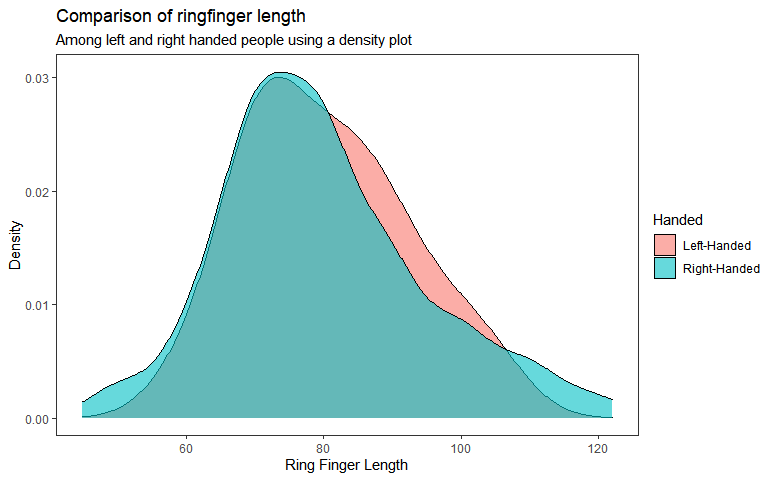

```r
ggplot(ttest.data, aes(x = Ring_Fingerlength_mm,
                       fill = Handed)) +
  geom_density(alpha = .6) +
  theme_test() +
  labs(x = "Ring Finger Length",
       y = "Density",
       title = "Comparison of ringfinger length",
       subtitle = "Among left and right handed people using a density plot")
```

# Elaboration